# IODS course project

# Logistic regression analysis

The four assumptions described before appeared to be suitable except for health and G3, based on the summary and images above. The next stage is to do a statistical analysis of the association between my chosen explanatory factors and the binary high-or low-alcohol intake variable as the goal variable, using logistic regression.

```r
m <- glm(high_use ~  + health + goout + absences + G3, data = alc, family = "binomial")

summary(m)
```

```
##
## Call:
## glm(formula = high_use ~ +health + goout + absences + G3, family = "binomial",
##     data = alc)
##
## Deviance Residuals:
##     Min       1Q   Median       3Q      Max
## -1.8342  -0.7505  -0.5508   0.9357   2.3172
##
## Coefficients:
##             Estimate Std. Error z value Pr(>|z|)
## (Intercept) -3.70363    0.79076  -4.684 2.82e-06 ***
## health       0.15179    0.09209   1.648 0.099275 .
## goout        0.72459    0.11941   6.068 1.29e-09 ***
## absences     0.07436    0.02212   3.362 0.000773 ***
## G3          -0.03852    0.03935  -0.979 0.327587
## ---
## Signif. codes:  0 '***' 0.001 '**' 0.01 '*' 0.05 '.' 0.1 ' ' 1
##
## (Dispersion parameter for binomial family taken to be 1)
##
##     Null deviance: 452.04  on 369  degrees of freedom
## Residual deviance: 386.07  on 365  degrees of freedom
## AIC: 396.07
##
## Number of Fisher Scoring iterations: 4
```

```r
coef(m)
```

```
## (Intercept)      health       goout    absences          G3
## -3.70363174  0.15179099  0.72459398  0.07435996 -0.03852050
```

The fitted model’s summary shows that alcohol use has a relatively strong link with all other variables except G3 final grade outcomes and health. Alcohol intake is well explained by going out with friends, and the frequency of school absences, and the findings are statistically significant.

The next step is to present and interpret the coefficients of the model as odds ratios.

```r
OR <- exp(coef(m))
OR
```

```
## (Intercept)      health       goout    absences          G3
##   0.0246339   1.1639169   2.0638929   1.0771945   0.9622120
```

```r
CI <-exp(confint(m))
cbind(OR, CI)
```

```
##                    OR       2.5 %    97.5 %
## (Intercept) 0.0246339 0.004960425 0.1109072
## health      1.1639169 0.973629481 1.3981834
## goout       2.0638929 1.642693029 2.6260422
## absences    1.0771945 1.033123265 1.1280521
## G3          0.9622120 0.890726272 1.0397748
```

# Prediction of the model

The new fitted model is created and calculated by removing variable G3 and health, because they were not statistically significant

```r
m <- glm(high_use ~ goout + absences, data = alc, family = "binomial")
summary(m)
```

```
##
## Call:
## glm(formula = high_use ~ goout + absences, family = "binomial",
##     data = alc)
##
## Deviance Residuals:
##     Min       1Q   Median       3Q      Max
## -1.9060  -0.7495  -0.5191   0.9438   2.3700
##
## Coefficients:
##             Estimate Std. Error z value Pr(>|z|)
## (Intercept) -3.63280    0.43792  -8.296  < 2e-16 ***
## goout        0.73380    0.11786   6.226 4.78e-10 ***
## absences     0.07632    0.02225   3.430 0.000602 ***
## ---
## Signif. codes:  0 '***' 0.001 '**' 0.01 '*' 0.05 '.' 0.1 ' ' 1
##
## (Dispersion parameter for binomial family taken to be 1)
##
##     Null deviance: 452.04  on 369  degrees of freedom
## Residual deviance: 390.30  on 367  degrees of freedom
## AIC: 396.3
##
## Number of Fisher Scoring iterations: 4
```

```r
cbind(exp(coef(m)), exp(confint(m)))
```

```
##                             2.5 %     97.5 %
## (Intercept) 0.02644199 0.01082308 0.06045431
## goout       2.08298255 1.66258410 2.64170298
## absences    1.07930582 1.03477610 1.13034717
```

The statistics above show that the new model contains explanatory variables that are statistically significant. The confidence intervals show that the model can be used for predictions.

```r
probabilities <- predict(m, type = "response")
# Add the predicted probabilities to 'alc'
alc <- mutate(alc, probability = probabilities)
# Use the probabilities to make a prediction of high_use
alc <- mutate(alc, prediction = probability > 0.5)
# Tabulate the target variable versus the predictions
tbl <- table(high_use = alc$high_use, prediction = alc$prediction)
addmargins(tbl)
```

```
##         prediction
## high_use FALSE TRUE Sum
##    FALSE   236   23 259
##    TRUE     65   46 111
##    Sum     301   69 370
```

```r
round(addmargins(prop.table(tbl)), 2)
```

```
##         prediction
## high_use FALSE TRUE  Sum
##    FALSE  0.64 0.06 0.70
##    TRUE   0.18 0.12 0.30
##    Sum    0.81 0.19 1.00
```

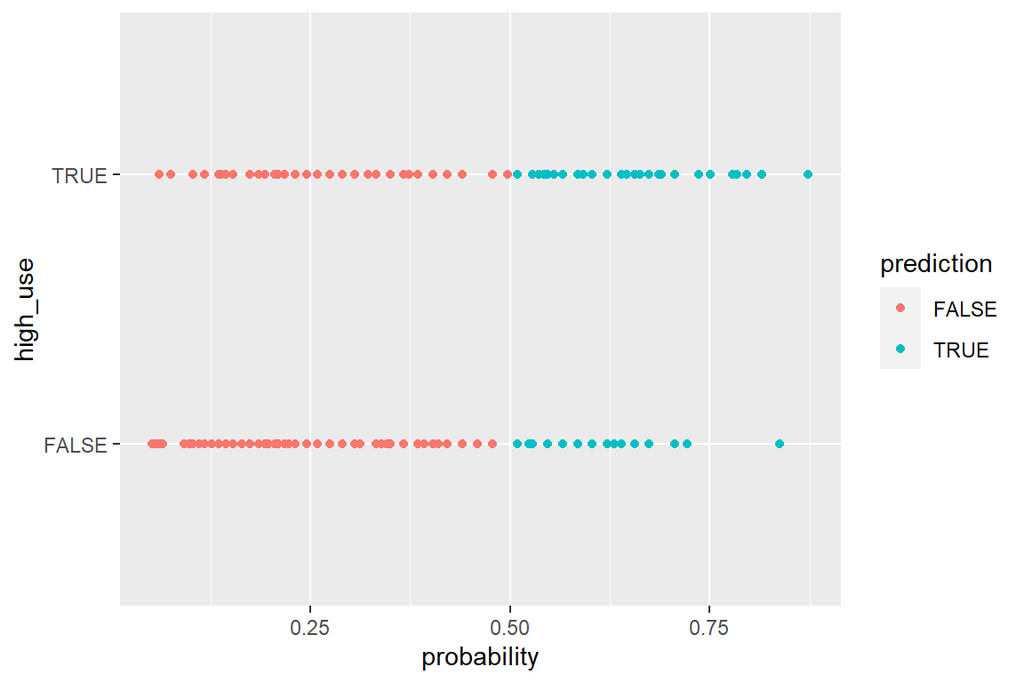

```r
g <- ggplot(alc, aes(x = probability, y = high_use, col = prediction))

# define the geom as points and draw the plot
g + geom_point()
```

```r
# tabulate the target variable versus the predictions
table(high_use = alc$high_use, prediction = alc$prediction) %>% prop.table %>% addmargins
```

```
##         prediction
## high_use      FALSE       TRUE        Sum
##    FALSE 0.63783784 0.06216216 0.70000000
##    TRUE  0.17567568 0.12432432 0.30000000
##    Sum   0.81351351 0.18648649 1.00000000
```

# Proportion of inaccurately classified individuals (= the training error)

We can compute the average amount of wrong predictions since we know how to make predictions with our model. First define a loss function (mean prediction error)

```r
loss_func = function(class, prob) {
  n_wrong = abs(class - prob) > 0.5
  mean(n_wrong)
}

loss_func(class = alc$high_use, prob = alc$probability)
```

```
## [1] 0.2378378
```

The training error is 23.7%, implying that the model’s accuracy is somewhat higher than 76%. The precision isn’t great, but as we’ve seen, my selection of explanatory factors wasn’t perfect either. Because only few explanatory variables were statistically significant, the findings from the guessing technique were no better.

# Cross validation (bonus task)

Cross validation is a method of testing a predictive model on unseen data. In cross-validation, the value of a penalty (loss) function (mean prediction error) is computed on data not used for finding the model. Low value = good.

```r
loss_func <- function(class, prob) {
  n_wrong <- abs(class - prob) > 0.5
  mean(n_wrong)
}

loss_func(class = alc$high_use, prob = alc$probability)
```

```
## [1] 0.2378378
```

```r
library(boot)
cv <- cv.glm(data = alc, cost = loss_func, glmfit = m, K = 10)
cv$delta[1]
```

```
## [1] 0.2405405
```

The average number of wrong predictions of my model were lower than in DataCamp (which had about 0.26 error). Indicating that my model was better. ***